# Aides Drug

Kelly Douglas

Fall 2019

# Introduction

For this test I will be seeing if the new drug for aides is affected based on if you are a female. Are more females getting Aides with the drug or not? $H_0$: There is no correlation between a person being a female and them having the medication work to not get Aids. $H_A$: If a person is a female then the drug will not work for them.

# Methods

For this question I will be using the barchart and chisq test and the fisher test to decide if there is a correlation between being a female and if the new Aides drug works.

# Results

## Descriptive Results

### Graphical Descriptive Results

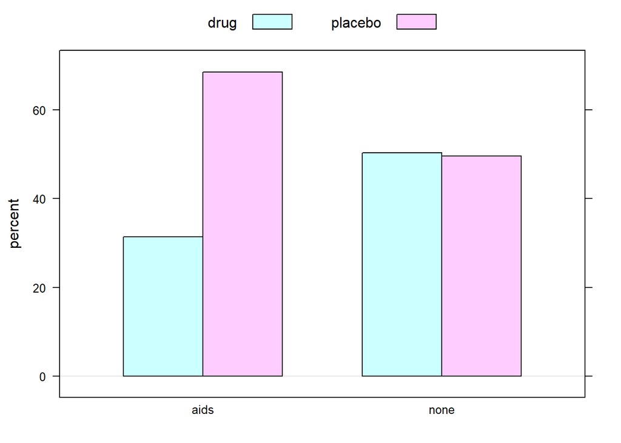

```r
barchartGC(~infected+treatment,data=avastf,type="percent")
```

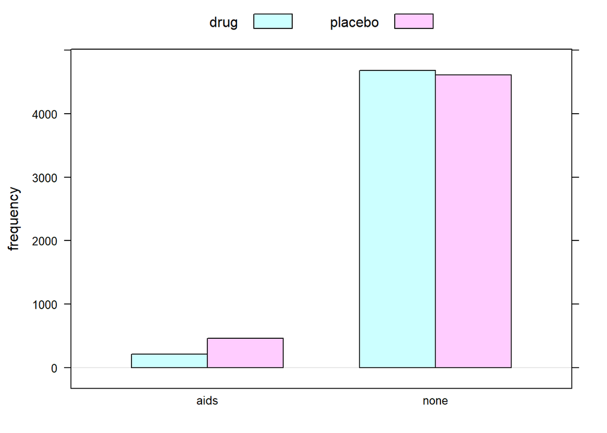

```r
barchartGC(~infected+treatment,data = avastf)
```

Based on the data above there is a smaller percent of females that got Aides taking the drug than those that took the placebo. The drug is effective since less females contracted aides that took the drug than those that took the placebo.

### Numerical Descriptive Results

```r
table1 <- xtabs(~infected+treatment,data=avastf)
rowPerc(table1)
```

```
##         treatment
## infected   drug placebo  Total
##     aids  31.42   68.58 100.00
##     none  50.38   49.62 100.00
```

```r
colPerc(table1)
```

```
##         treatment
## infected   drug placebo
##    aids    4.35    9.16
##    none   95.65   90.84
##    Total 100.00  100.00
```

Based on the data above less females got the disease that took the drug than those that took the placebo. So the drug is effective for females.

## Inferential Results

```r
chisq.test(table1)
```

```
##
##  Pearson's Chi-squared test with Yates' continuity correction
##
## data:  table1
## X-squared = 90.194, df = 1, p-value < 2.2e-16
```

```r
chisqtestGC(table1)
```

```
## Pearson's Chi-squared test with Yates' continuity correction
##
## Observed Counts:
##         treatment
## infected drug placebo
##     aids  213     465
##     none 4684    4613
##
## Counts Expected by Null:
##         treatment
## infected    drug placebo
##     aids  332.85  345.15
##     none 4564.15 4732.85
##
## Contributions to the chi-square statistic:
##         treatment
## infected  drug placebo
##     aids 43.15   41.62
##     none  3.15    3.03
##
##
## Chi-Square Statistic = 90.1943
## Degrees of Freedom of the table = 1
## P-Value = 0
```

```r
fisher.test(table1)
```

```
##
##  Fisher's Exact Test for Count Data
##
## data:  table1
## p-value < 2.2e-16
## alternative hypothesis: true odds ratio is not equal to 1
## 95 percent confidence interval:
##  0.3798342 0.5345407
## sample estimates:
## odds ratio
##  0.4511536
```

Based on the information above the p-value is very small. It shows that the drug is effective for females. It shows that the amount that contracted aids taking the drug was smaller than those that contracted aids taking the placebo.

# Discussion and Conclusion

This drug is effective for females. Based on the p-value I reject the null hypothesis. It is an effective drug.